# Analysis of the Carpentries Long-Term Feedback Survey: Round 2

Contributors: [Kari L. Jordan](https://github.com/kariljordan), [Naupaka Zimmerman](https://github.com/naupaka), [Marianne Corvellec](https://github.com/mkcor), [Elizabeth Wickes](https://github.com/elliewix), [Jonah Duckles](https://github.com/jduckles)

### Demographics

**Respondents Status**

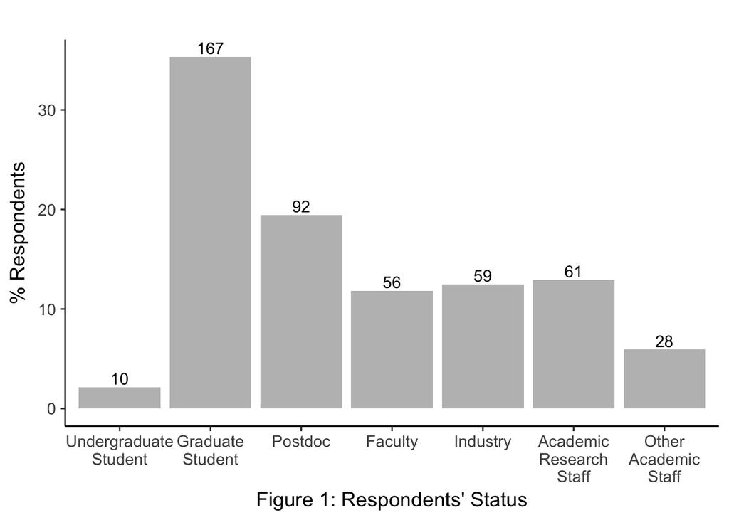

**Field of work, research, or study.**

| Field | n | % |
| --- | --- | --- |
| Life Sciences | 175 | 36.2 |
| Biomedical/Health Sciences | 104 | 21.5 |
| Agricultural or Environmental Sciences | 81 | 16.8 |
| Physical Sciences | 57 | 11.8 |
| Earth Sciences | 50 | 10.4 |
| Mathematics or Statistics | 43 | 8.9 |
| Engineering | 42 | 8.7 |
| Computer Science | 38 | 7.9 |
| Social Sciences | 25 | 5.2 |
| Library Sciences | 21 | 4.3 |
| Humanities | 14 | 2.9 |
| Business | 6 | 1.2 |

**Number of Carpentries workshops attended**

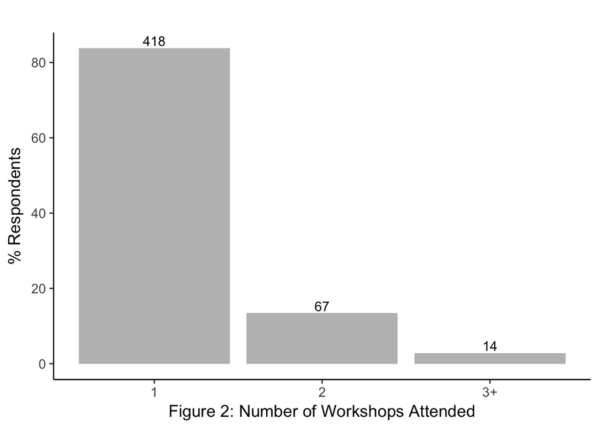

**Time since completing last Carpentries workshop**

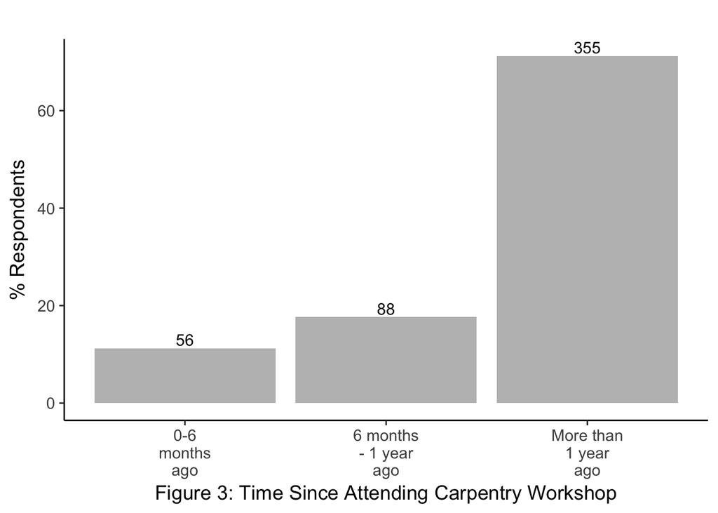

# Workshop Content

**What content was covered at the last Carpentries workshop you completed? Select all that apply.**

Tools Covered

| ContentCovered | n |
| --- | --- |
| Git | 378 |
| Python | 301 |
| Unix Shell | 291 |
| R | 200 |
| SQL | 139 |
| I don’t remember. | 32 |
| OpenRefine | 29 |
| Spreadsheets | 21 |
| Cloud Computing | 15 |
| MATLAB | 5 |
| Mercurial | 3 |

**Combination of tools covered in respondents’ workshops.**

Combination of Tools Covered

| Frequency of Tools Covered | n | % |
| --- | --- | --- |
| Git Python Unix Shell | 96 | 19.0 |
| Git Python | 41 | 8.1 |
| Git Python SQL Unix Shell | 39 | 7.7 |
| Git R Unix Shell | 31 | 6.2 |
| Git R | 22 | 4.4 |
| Git Python R Unix Shell | 19 | 3.8 |
| Git Unix Shell | 17 | 3.4 |
| Git Python SQL | 16 | 3.2 |
| R | 15 | 3.0 |
| Git R SQL Unix Shell | 12 | 2.4 |

**Matrix of combinations of tools covered.**

Matrix of Common Tools Covered

|  | Cloud Computing | Git | I don’t remember. | MATLAB | Mercurial | OpenRefine | Python | R | Spreadsheets | SQL | Unix Shell |
| --- | --- | --- | --- | --- | --- | --- | --- | --- | --- | --- | --- |
| Cloud Computing | 15 | 10 | 3 | 0 | 0 | 2 | 6 | 8 | 2 | 2 | 10 |
| Git | 10 | 378 | 18 | 4 | 2 | 14 | 256 | 139 | 9 | 115 | 257 |
| I don’t remember. | 3 | 18 | 32 | 0 | 0 | 1 | 8 | 16 | 1 | 6 | 9 |
| MATLAB | 0 | 4 | 0 | 5 | 0 | 0 | 4 | 2 | 0 | 3 | 3 |
| Mercurial | 0 | 2 | 0 | 0 | 3 | 0 | 3 | 0 | 0 | 1 | 3 |
| OpenRefine | 2 | 14 | 1 | 0 | 0 | 29 | 12 | 23 | 13 | 19 | 10 |
| Python | 6 | 256 | 8 | 4 | 3 | 12 | 301 | 68 | 6 | 91 | 202 |
| R | 8 | 139 | 16 | 2 | 0 | 23 | 68 | 200 | 20 | 67 | 104 |
| Spreadsheets | 2 | 9 | 1 | 0 | 0 | 13 | 6 | 20 | 21 | 17 | 11 |
| SQL | 2 | 115 | 6 | 3 | 1 | 19 | 91 | 67 | 17 | 139 | 85 |
| Unix Shell | 10 | 257 | 9 | 3 | 3 | 10 | 202 | 104 | 11 | 85 | 291 |

# Workshop Impact

**Behaviors Adopted**

Which of the following behaviors have you adopted as a result of completing a Carpentries workshop? Check all that apply.

| Behaviors_Adopted | n | % |
| --- | --- | --- |
| Using programming languages like R or Python, or the command line to automate repetitive tasks. | 274 | 66.2 |
| Improving data management and project organization. | 204 | 49.3 |
| Using version control to manage code. | 191 | 46.1 |
| Reusing code. | 180 | 43.5 |
| Sharing code or data publicly on places like GitHub or FigShare. | 128 | 30.9 |
| Using databases, scripts and queries to manage large data sets. | 124 | 30.0 |
| Using version control to collaborate online (in public or private repositories). | 123 | 29.7 |
| Transforming step-by-step workflows into scripts or functions. | 118 | 28.5 |
| Developing a data management and analysis plan. | 75 | 18.1 |

## Behaviors by Group

| Behaviors_Adopted | Academic Research Staff | Faculty | Graduate Student | Industry | Postdoc | Undergraduate Student |
| --- | --- | --- | --- | --- | --- | --- |
| Developing a data management and analysis plan. | 9.8 | 16.1 | 17.4 | 22.0 | 12.0 | 0 |
| Improving data management and project organization. | 39.3 | 48.2 | 41.3 | 45.8 | 41.3 | 0 |
| Reusing code. | 34.4 | 35.7 | 37.7 | 37.3 | 34.8 | 20 |
| Sharing code or data publicly on places like GitHub or FigShare. | 23.0 | 28.6 | 24.6 | 28.8 | 25.0 | 30 |
| Transforming step-by-step workflows into scripts or functions. | 24.6 | 19.6 | 26.9 | 27.1 | 26.1 | 20 |
| Using databases, scripts and queries to manage large data sets. | 19.7 | 19.6 | 25.7 | 28.8 | 31.5 | 10 |
| Using programming languages like R or Python, or the command line to automate repetitive tasks. | 59.0 | 53.6 | 58.1 | 59.3 | 59.8 | 20 |
| Using version control to collaborate online (in public or private repositories). | 26.2 | 32.1 | 19.2 | 44.1 | 21.7 | 40 |
| Using version control to manage code. | 45.9 | 42.9 | 33.5 | 61.0 | 31.5 | 30 |

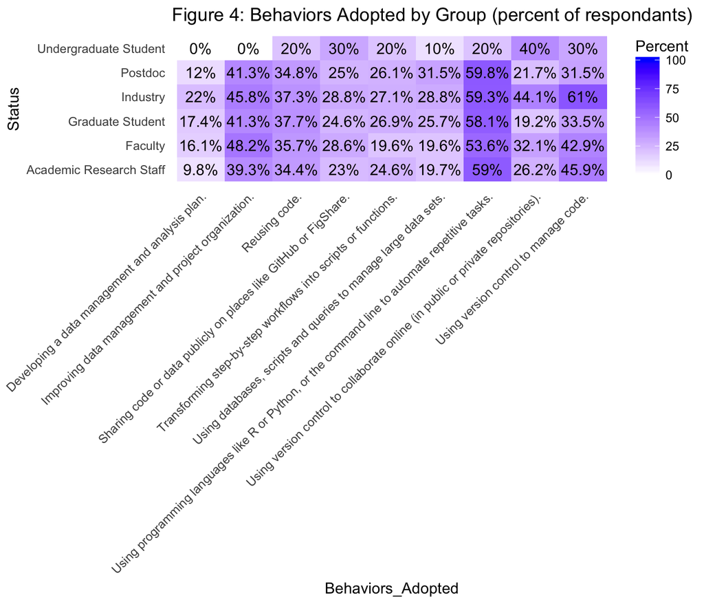

# Programming Usage Pre- and Post-Workshop

**Before completing a Carpentries workshop, how often did you use programming languages (R, Python, etc.), databases (Access, SQL, etc.), version control software and/or the shell?**

| ProgrammingBefore | n |
| --- | --- |
| Daily. | 123 |
| I had not been using tools like these. | 80 |
| Less than once per year. | 52 |
| Monthly. | 45 |
| Several times per year. | 74 |
| Weekly. | 84 |

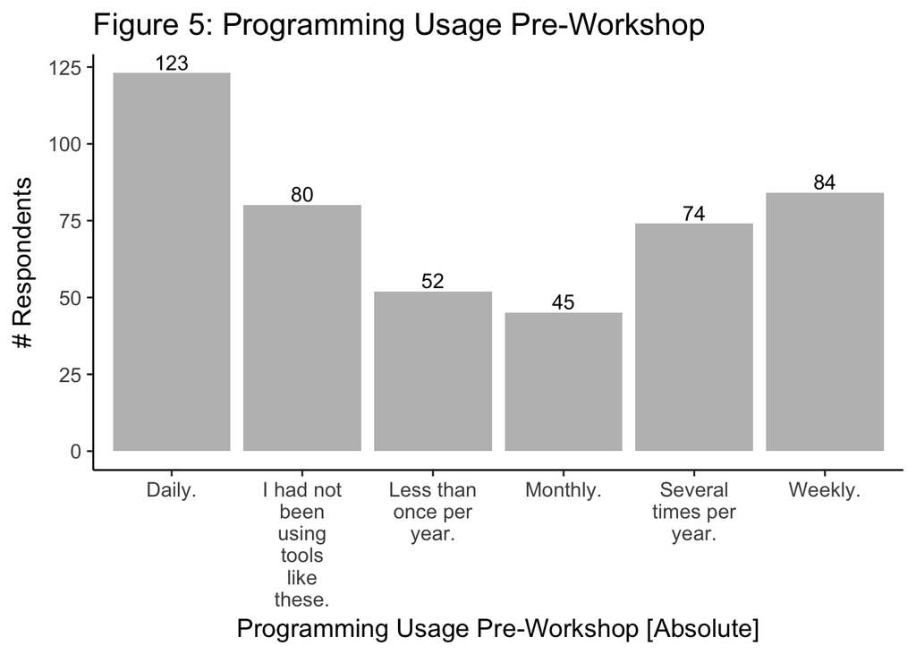

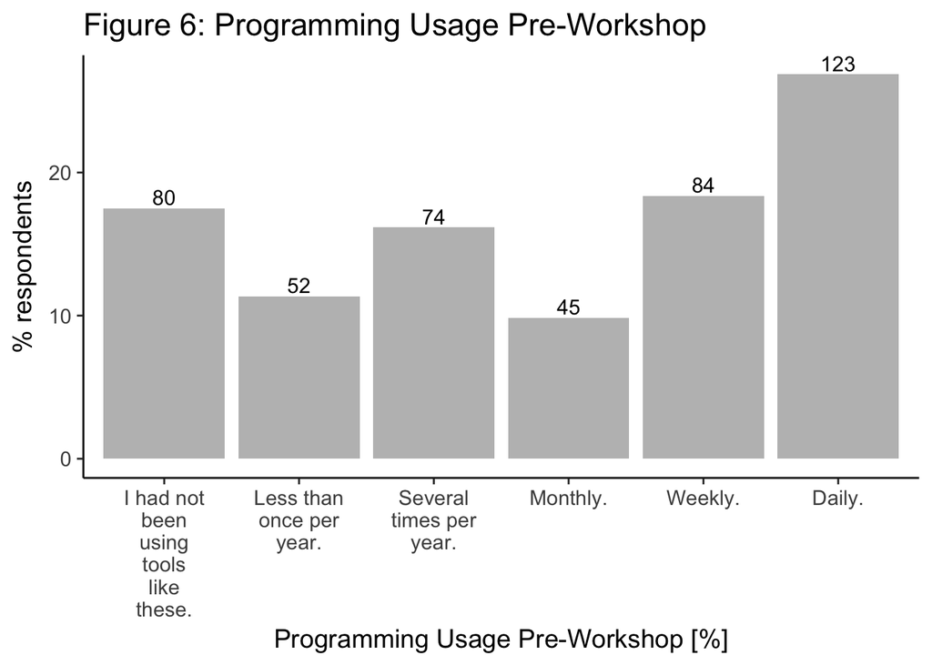

**Since completing a Carpentries workshop, how often do you currently use programming languages (R, Python, etc.), databases (Access, SQL, etc.), version control software and/or the shell?**

| ProgrammingSince | n |
| --- | --- |
| I have not been using tools like these. | 24 |
| Less than once per year. | 20 |
| Several times per year. | 68 |
| Monthly. | 50 |
| Weekly. | 101 |
| Daily. | 195 |

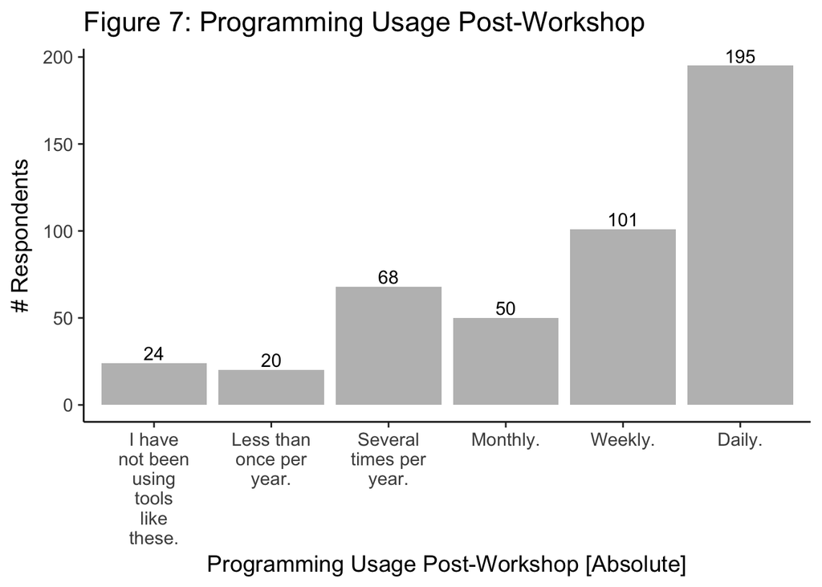

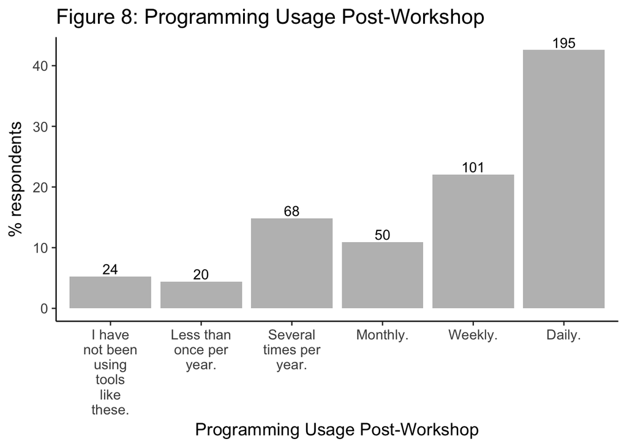

**Comparing pre/post programming usage**

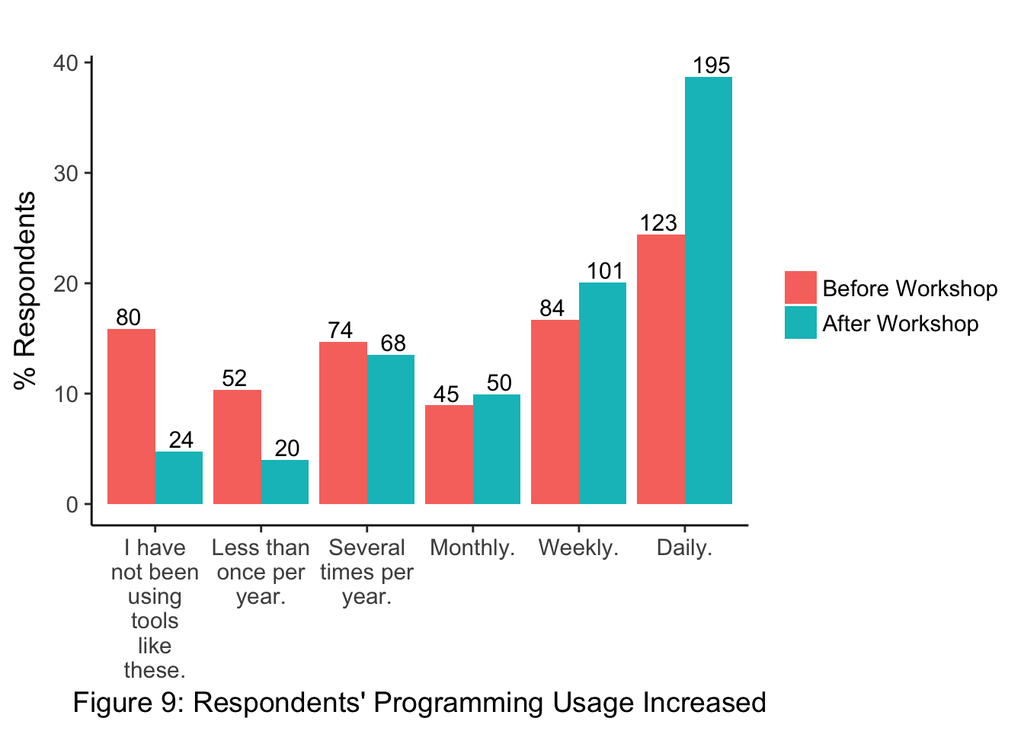

## Pre-post programming usage by group

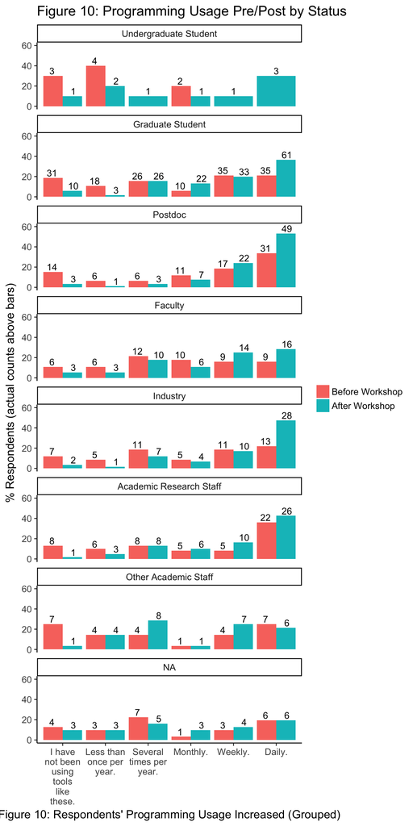

**Pre/Post Residuals**

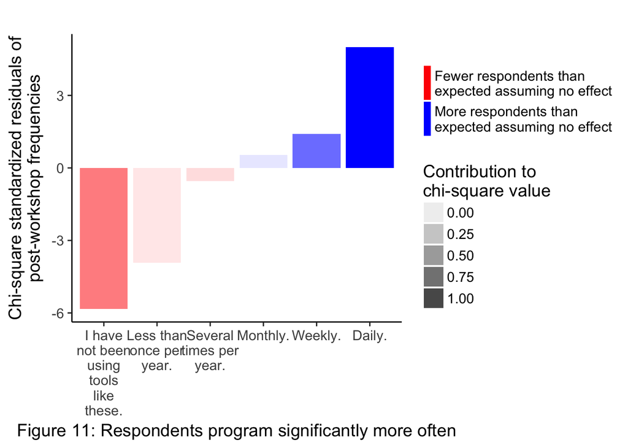

# Workshop Impact

**Change in Confidence**

How would you rate your change in confidence in the tools that were covered during your Carpentries workshops compared to before the workshop?

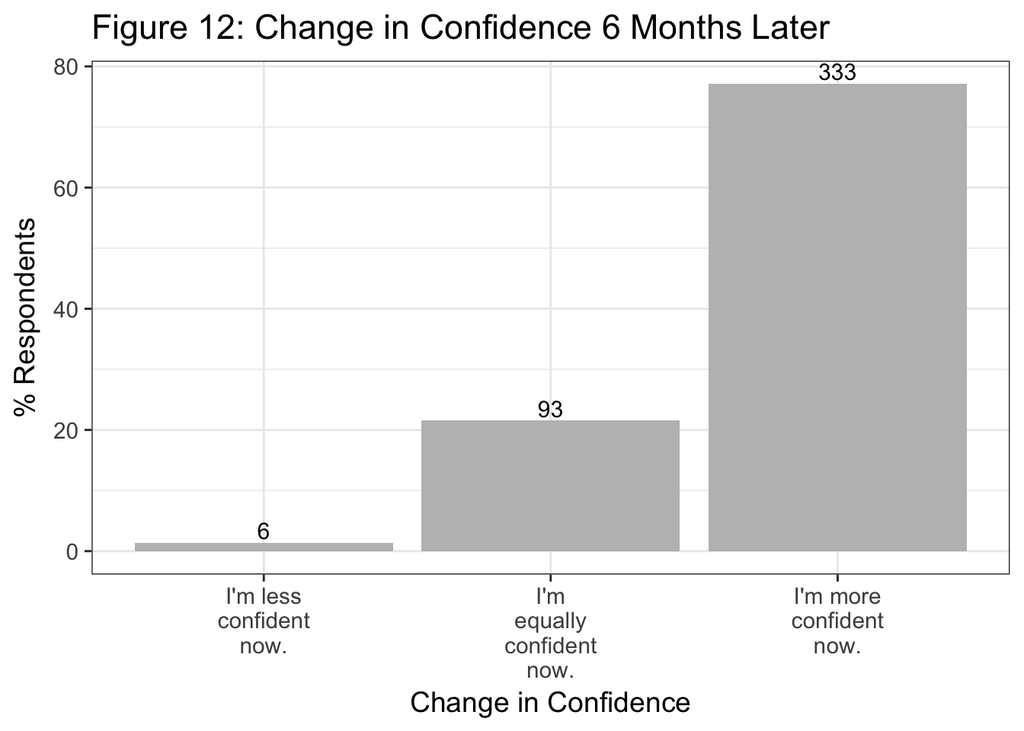

**Change in Confidence by Status**

```
## [1] "Undergraduate Student"   "Graduate Student"
## [3] "Postdoc"                 "Faculty"
## [5] "Academic Research Staff" "Other Academic Staff"
## [7] "Industry"
```

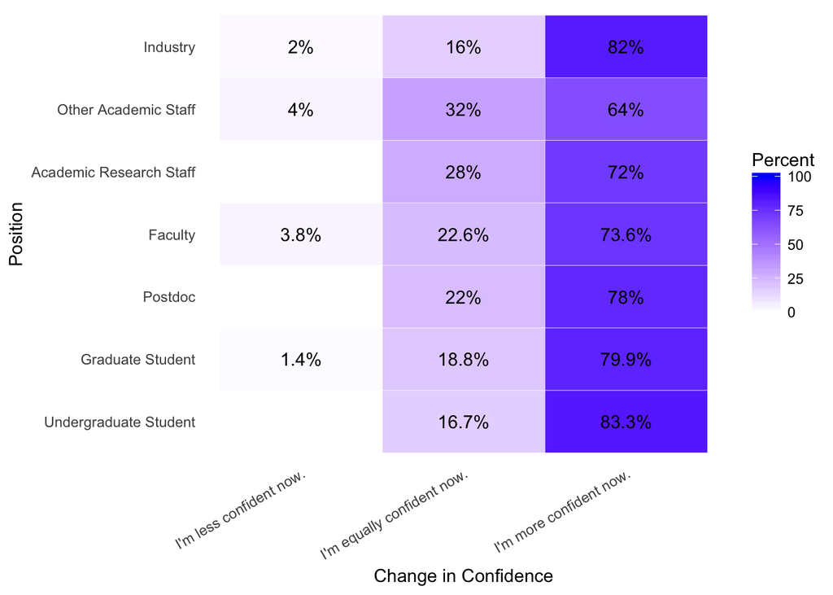

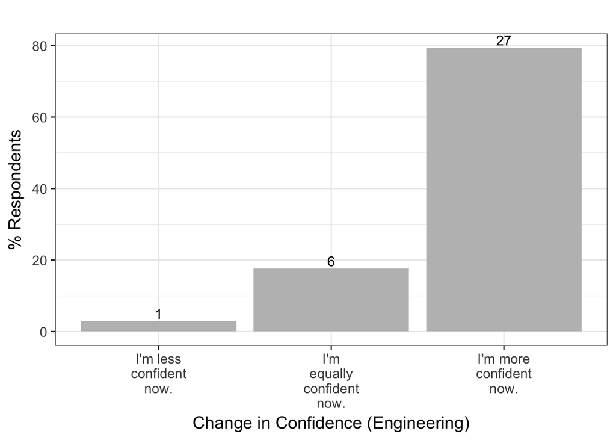

# Usage of Tools for Research and/or Work

If you are using the tools you learned in a Carpentries workshop, how are they helping you? Check all that apply.

| How Tools Covered Have Helped | n | % |
| --- | --- | --- |
| They are improving my overall efficiency. | 254 | 59.5 |
| They are improving my ability to analyze data. | 228 | 53.4 |
| They are improving my ability to manage data. | 214 | 50.1 |
| I am not using the tools I learned. | 65 | 15.2 |
| The tools I learned have not helped me with my work. | 30 | 7.0 |

# Contributions to Academic Writing

Has completing a Carpentries workshop contributed to your writing of a research article, thesis, dissertation, or grant proposal?

| Writing | n | % |
| --- | --- | --- |
| No. | 207 | 45.1 |
| Not sure. | 130 | 28.3 |
| Yes. | 122 | 26.6 |

# Perception of Workshop Impact

The statements below reflect ways in which completing a Carpentries workshop may have impacted you. Please indicate your level of agreement with these statements:

- I have used skills I learned at the workshop to advance my career.
- I have been motivated to seek more knowledge about the tools I learned at the workshop.
- I have made my analyses more reproducible as a result of completing the workshop.
- I have received professional recognition for my work as a result of using the tools I learned at the workshop.
- I have improved my coding practices as a result of completing the workshop.
- My research productivity has improved as a result of completing the workshop.
- I have gained confidence in working with data as a result of completing the workshop.

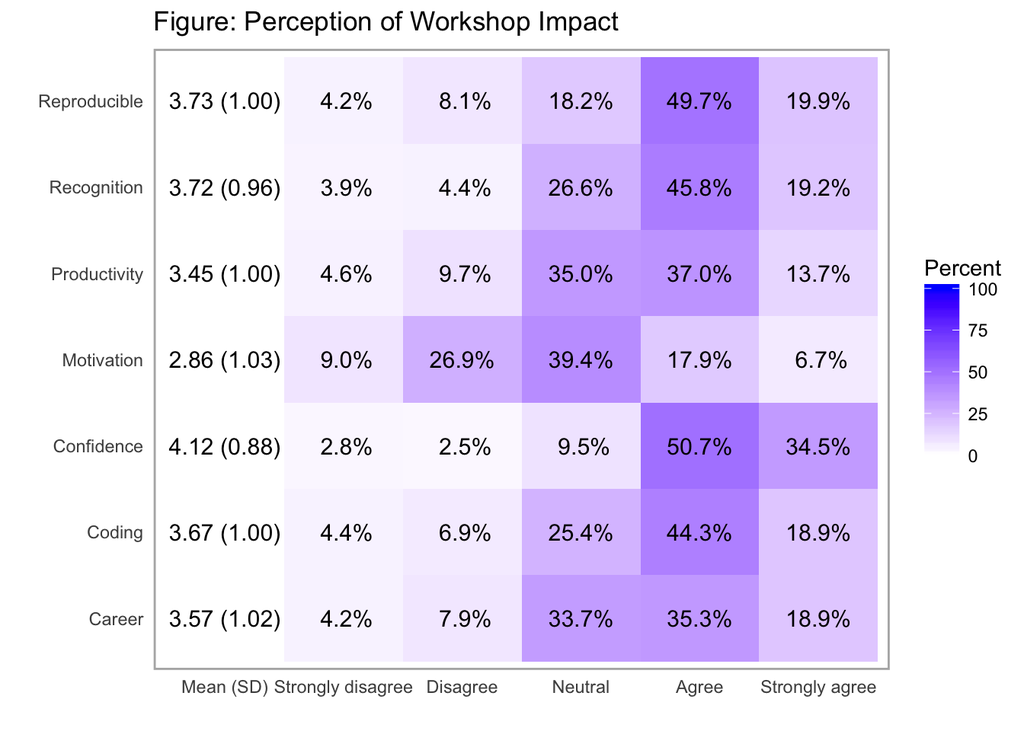

# Breakdown of respondents by Country

**In what country was the workshop you attended held?**

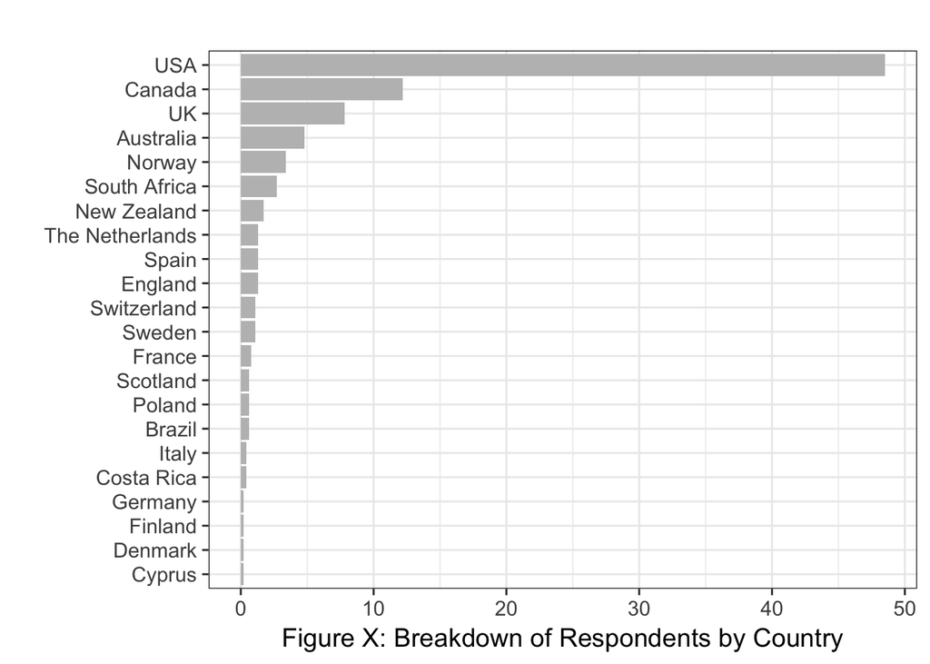

# Respondent Demographics

**What is your gender?**

Gender was added to the survey during the second round of data collection. We only have seven data points, so do not include this information in the report.

| Gender | n | perc |
| --- | --- | --- |
| Female | 4 | 57 |
| Male | 3 | 43 |

**How would you describe yourself?**

Ethnicity was added to the survey in the second round of data collection. We only have eight responses, so do not include this information in the report.

| Race | n | % |
| --- | --- | --- |
| White(A person having origins in any of the original peoples of Europe, the Middle East, or North Africa.) | 4 | 50.0 |
| Asian(A person having origins in any of the original peoples of the Far East, Southeast Asia, or the Indian subcontinent including, for example, Cambodia, China, India, Japan, Korea, Malaysia, Pakista… | 2 | 25.0 |
| Black or African American(A person having origins in any of the Black racial groups of Africa – includes Caribbean Islanders and other of African origin.) | 1 | 12.5 |
| I prefer not to say. | 1 | 12.5 |

| Number of Workshops Attended | n |
| --- | --- |
| 1 | 418 |
| 2 | 67 |
| 3+ | 14 |

| Time Since Last Attending Workshop | n |
| --- | --- |
| 0-6 months ago | 56 |
| 6 months - 1 year ago | 88 |
| More than 1 year ago | 355 |

| value | Academic Research Staff | Faculty | Graduate Student | Industry | Other (please specify) | Other Academic Staff | Postdoc | Undergraduate Student |
| --- | --- | --- | --- | --- | --- | --- | --- | --- |
| Agricultural or Environmental Sciences | 4 | 4 | 35 | 9 | 0 | 5 | 15 | 1 |
| Biomedical/Health Sciences | 16 | 8 | 28 | 16 | 0 | 6 | 25 | 1 |
| Business | 1 | 0 | 0 | 4 | 0 | 1 | 0 | 0 |
| Computer Science | 2 | 3 | 12 | 11 | 0 | 3 | 3 | 2 |
| Earth Sciences | 12 | 4 | 19 | 3 | 0 | 4 | 6 | 0 |
| Engineering | 4 | 4 | 18 | 10 | 0 | 2 | 1 | 1 |
| Humanities | 4 | 2 | 1 | 1 | 0 | 3 | 2 | 1 |
| Library Sciences | 2 | 8 | 1 | 0 | 0 | 7 | 1 | 0 |
| Life Sciences | 17 | 19 | 67 | 12 | 0 | 7 | 47 | 2 |
| Mathematics or Statistics | 6 | 3 | 7 | 10 | 0 | 4 | 5 | 4 |
| Physical Sciences | 8 | 5 | 25 | 0 | 0 | 2 | 12 | 1 |
| Social Sciences | 6 | 6 | 5 | 2 | 0 | 2 | 3 | 0 |

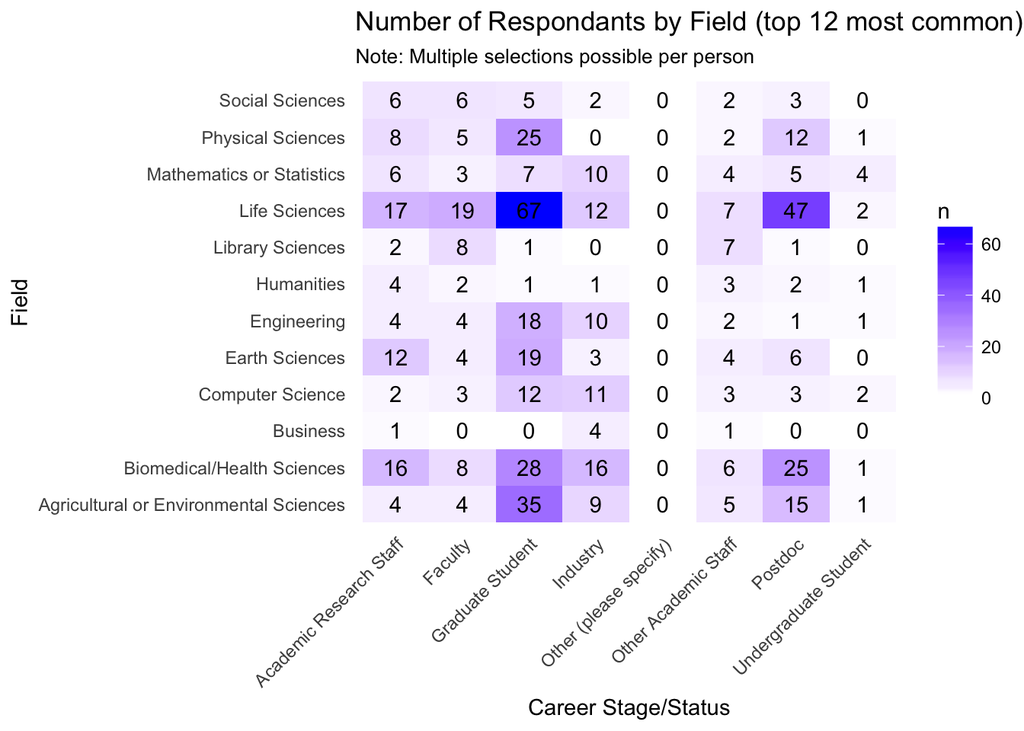

# Involvement in the Carpentries

Please indicate your involvement in the Carpentry community since completing a Carpentry workshop. Check all that apply.

| Involvement Since Attending a Carpentry Workshop | n |
| --- | --- |
| Subscribed to the newsletter. | 128 |
| Became a workshop helper. | 33 |
| Became a Carpentry instructor. | 28 |
| Contributed to a Carpentry lesson. | 21 |
| Attended at least one community call. | 20 |
| Joined a mentoring group. | 13 |
| Participated in a Twitter chat. | 11 |
| Joined a committee. | 7 |

**Matrix of involvement**

Matrix of Common Involvement

|  | Attended at least one community call. | Became a Carpentry instructor. | Became a workshop helper. | Contributed to a Carpentry lesson. | Joined a committee. | Joined a mentoring group. | Participated in a Twitter chat. | Subscribed to the newsletter. |
| --- | --- | --- | --- | --- | --- | --- | --- | --- |
| Attended at least one community call. | 20 | 17 | 11 | 14 | 3 | 7 | 4 | 16 |
| Became a Carpentry instructor. | 17 | 28 | 16 | 19 | 4 | 10 | 4 | 19 |
| Became a workshop helper. | 11 | 16 | 33 | 12 | 2 | 6 | 2 | 19 |
| Contributed to a Carpentry lesson. | 14 | 19 | 12 | 21 | 3 | 8 | 4 | 15 |
| Joined a committee. | 3 | 4 | 2 | 3 | 7 | 4 | 1 | 3 |
| Joined a mentoring group. | 7 | 10 | 6 | 8 | 4 | 13 | 2 | 9 |
| Participated in a Twitter chat. | 4 | 4 | 2 | 4 | 1 | 2 | 11 | 4 |
| Subscribed to the newsletter. | 16 | 19 | 19 | 15 | 3 | 9 | 4 | 128 |

# Continuous Learning

Which of the following learning activities (for data management and analysis) have you participated in since completing a Carpentry workshop? Check all that apply.

| Continuous Learning | n | % |
| --- | --- | --- |
| Used non-Carpentry self-guided material. | 135 | 35 |
| Used self-guided Carpentry lesson material. | 72 | 19 |
| Participated in an in-person short course. | 63 | 17 |
| Participated in an online short course. | 48 | 13 |
| Participated in a Meetup. | 35 | 9 |
| Participated in a semester long course. | 28 | 7 |

**Matrix of continuous learning activities**

Matrix of Common Post-Workshop Learning Activities

|  | Participated in a Meetup. | Participated in a semester long course. | Participated in an in-person short course. | Participated in an online short course. | Used non-Carpentry self-guided material. | Used self-guided Carpentry lesson material. |
| --- | --- | --- | --- | --- | --- | --- |
| Participated in a Meetup. | 35 | 8 | 12 | 16 | 17 | 9 |
| Participated in a semester long course. | 8 | 28 | 8 | 9 | 13 | 4 |
| Participated in an in-person short course. | 12 | 8 | 63 | 16 | 19 | 13 |
| Participated in an online short course. | 16 | 9 | 16 | 48 | 27 | 9 |
| Used non-Carpentry self-guided material. | 17 | 13 | 19 | 27 | 135 | 37 |
| Used self-guided Carpentry lesson material. | 9 | 4 | 13 | 9 | 37 | 72 |

# Recommending Carpentries Workshops

**Have you recommended a Carpentry workshop to a friend or colleague?**

| Recommended a Workshop? | n | % |
| --- | --- | --- |
| Yes. | 316 | 74 |
| No. | 66 | 16 |
| I don’t remember. | 43 | 10 |